# Homework 8 - BIOS 6643

Dominic Adducci

2023-11-02

## Exam Q5

Intercept: For the baseline (first year evaluation), the subjects have an expected value of 13.18 from the logical memory scale test. The p-value of 0.0000 is statistically significant, assuming an $\alpha$ of 0.05. Because the intercept is not accounting for between subject differences the SE is larger compared to the slope effect.

Eval.Num: For each subsequent yearly observation the subjects are expected to decrease by ~ 0.0826 per yer on the logical memory scale. The p-value of 0.1252 is not statistically significant. The SE is smaller because the degree of freedom for the within subject covariate of time is closer to the number of observations.

## Exam Q6

The above was run with the REML method, so AIC/BIC cannot be accurately applied (need ML to do this).

## Question 1

Write the generalized linear mixed model notation for the general case and for a model with one covariates and a random intercept, and one covariates and a random intercept and slope models for a count outcome. Define the distribution you will use, mean, variance, systematic component (for the three different models), and the random effects distribution. For the random effects define the different dimensions of the Normal distribution.

**Generalized Case**
$$\eta_{ij} = X_{ij}^T\beta + Z_{ij}^Tb_i$$
$$g(E[Y_{ij}|b_i]) = \eta_{ij}$$
$$Var(Y_{ij}|b_i) =
Var[E[Y_{ij}|b_i]]\phi$$

- $i = 1...n$: where n is the number of subjects.
- $j = 1...n_i$: $n_i$ number of observations for a subject.
- For the general model G has dimensions of (qxq).

**Model with one covariate and a random intercept:** A count outcome will require a Poisson model.
$$\eta_{ij} = \beta_0 + \beta_1X_{ij} +
b_{i0}$$
$$log(E[Y_{ij}|b_i]) =
n_{ij}$$
$$E[Y_{ij}|b_i] = e^{\beta_0
+ \beta_1X_{ij} + b_{i0}}$$
$$Var[Y_{ij}|b_i] = \phi E[Y_{ij}|b_i]$$
The distribution of the random effect is $b_i \sim N(0,G_i)$, where $G_i$ has dimensions of (qxq). Because this is a random intercept only model q is equal to 1, so $G_i$ has dimensions of (1x1).

**Model with one covariate and a random intercept and slope:** This will again require a Poisson distribution.
$$\eta_{ij} = \beta_0 + \beta_1X_{ij} + b_{i0} +
b_{1j}X_{ij}$$
$$log(E[Y_{ij}|b_i]) =
n_{ij}$$
$$E[Y_{ij}|b_i] = e^{\beta_0
+ \beta_1X_{ij} + b_{i0} + b_{1j}X_{ij}}$$
$$Var[Y_{ij}|b_i] = \phi E[Y_{ij}|b_i]$$
The distribution of the random effect is $b_i \sim N(0,G_i)$, where $G_i$ has dimensions of (qxq). Because this is a random intercept and slope model q is equal to 2, so $G_i$ has dimensions of (2x2).

# Question 2

Note: the nAGQ parameter is for the estimation algorithm, which we will be covering in class next week.

Interpret the age and sex effects (and the interaction term) assuming the interaction is significant with a negative coefficient. Age has a positive coefficient and Sex a negative coefficient. Be precise in your interpretation reflecting the new interpretations for GLMM’s.

This is a binomial model, meaning a binary outcome. The coefficients will be odds ratios, which in this case will be the odds ratio of being obese versus not being obese. Men are assumed to be the reference group for the interpretation of effects.

**Effects:**

- $e^{\beta_0}$: The intercept is the odds ratio of being obese vs non-obese for the average male subject at 0 years of age. Not interpretable in this analysis. There is also a random intercept, meaning each subject has different start points.
- $e^{\beta_{Age}}$: Age has a positive coefficient meaning that as the average subject ages the odds ratio of being obese versus not obese increases. There is a random slope for age meaning that individual subjects have different trajectories as they age. Some subjects individual trajectories may increase or decrease, but the population level effect is fixed as positive (increasing odds ratio). Because the reference group is men the Age coefficient applies to men aging.
- $e^{\beta_{Sex}}$: Sex has a negative coefficient meaning that the average female in the population has a lower odds ratios of being obese versus non-obese compared to men.
- $e^{Age + Sex + Age*Sex}$: Including the interaction term with the age and sex coefficients describes the odds ratio of being obese versus non-obese for women as they age compared to men.

# Question 3

Read in the datasets for your project and perform data cleaning. Make a Table 1 and 3 graphs of the data and write 2 questions about your project that you have for Jared and Nichole.

Cleaning Data:

There are more subjects in the clinical data than the variogram data. Will need to select subjects from the clinical data based on the variogram data. Will also select out variogram data based on the project 2 indicator. The data frames will be combined by ID.

Table 1: Clinical Data

|  | Overall (N=337) |
| --- | --- |
| Age |  |
| Mean (SD) | 52.9 (9.99) |
| Median [Min, Max] | 53.4 [26.3, 77.3] |
| Missing | 2 (0.6%) |
| BMI |  |
| Mean (SD) | 30.6 (6.42) |
| Median [Min, Max] | 29.7 [18.2, 51.8] |
| Gender |  |
| Female | 181 (53.7%) |
| Male | 154 (45.7%) |
| Missing | 2 (0.6%) |
| Height |  |
| Mean (SD) | 66.9 (4.03) |
| Median [Min, Max] | 67.0 [54.0, 77.0] |
| Race |  |
| American Indian or Alaska Native | 2 (0.6%) |
| Asian | 3 (0.9%) |
| Black or African American | 80 (23.7%) |
| Multi-racial or No Primary Race | 4 (1.2%) |
| Unknown | 2 (0.6%) |
| White | 244 (72.4%) |
| Missing | 2 (0.6%) |
| Ground Glass |  |
| 0 | 220 (65.3%) |
| 1 | 66 (19.6%) |
| 2 | 44 (13.1%) |
| 3 | 6 (1.8%) |
| Missing | 1 (0.3%) |
| Traction Bronchiectasis |  |
| 0 | 200 (59.3%) |
| 1 | 80 (23.7%) |
| 2 | 38 (11.3%) |
| 3 | 18 (5.3%) |
| Missing | 1 (0.3%) |
| Fibrosis |  |
| 0 | 300 (89.0%) |
| 1 | 36 (10.7%) |
| Missing | 1 (0.3%) |
| Interlobular Septal Thick |  |
| 0 | 279 (82.8%) |
| 1 | 56 (16.6%) |
| 2 | 1 (0.3%) |
| Missing | 1 (0.3%) |
| Mosaic Attenuation |  |
| 0 | 244 (72.4%) |
| 1 | 58 (17.2%) |
| 2 | 31 (9.2%) |
| 3 | 3 (0.9%) |
| Missing | 1 (0.3%) |
| Med Lymphadenopathy |  |
| 0 | 151 (44.8%) |
| 2 | 14 (4.2%) |
| 3 | 171 (50.7%) |
| Missing | 1 (0.3%) |
| FEV1 |  |
| Mean (SD) | 2.70 (0.952) |
| Median [Min, Max] | 2.58 [0.740, 5.78] |
| Missing | 11 (3.3%) |
| FVC |  |
| Mean (SD) | 3.60 (1.14) |
| Median [Min, Max] | 3.45 [1.12, 7.27] |
| Missing | 11 (3.3%) |
| FEV/FVC |  |
| Mean (SD) | 0.752 (0.112) |
| Median [Min, Max] | 0.775 [0.258, 0.976] |
| Missing | 11 (3.3%) |

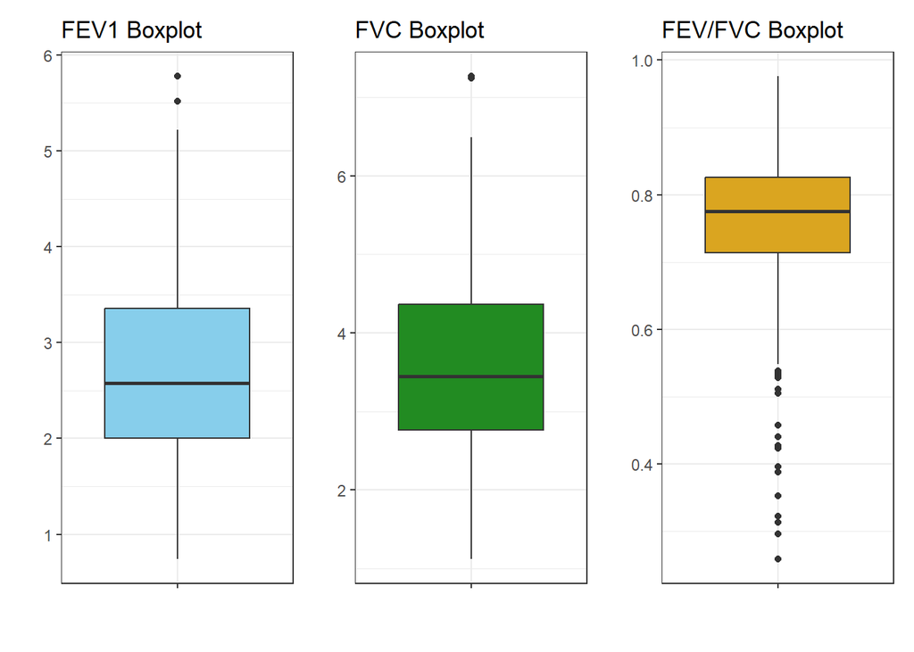

The above boxplots show the distribution for FEV1, FVC, and FEV1/FVC for the entire data set. FEV1/FVC seems to have more spread so the boxplots by race will be plotted to see if there is a difference in distribution for each race group.

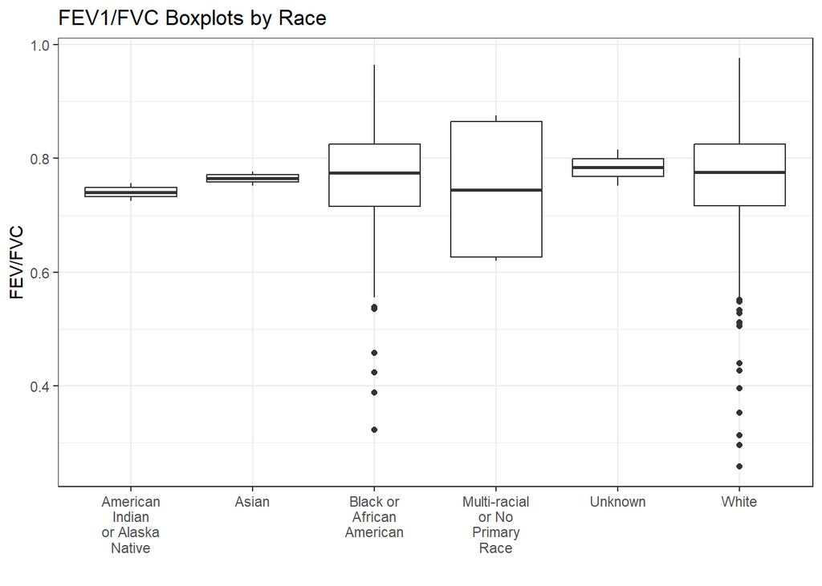

The above boxplots show the distribution of FEV1/FVC for each race category.

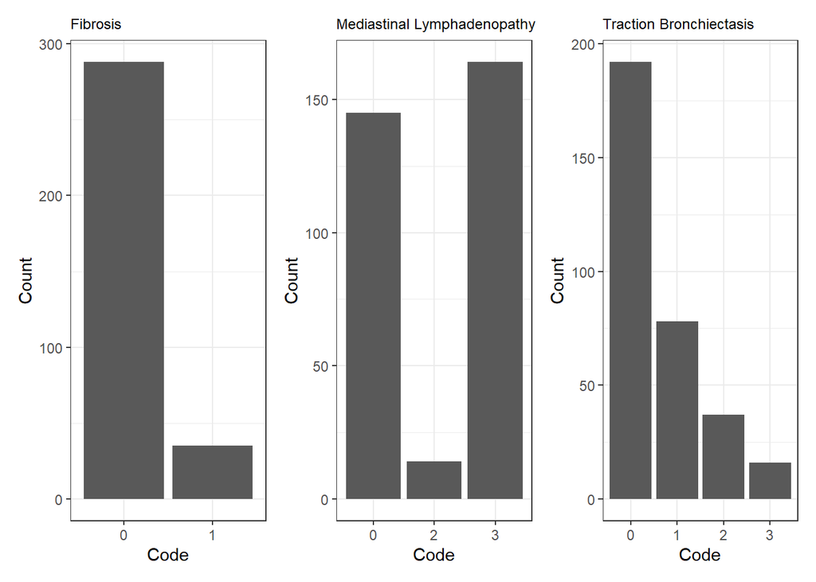

The above bar plots show the occurrences of different codes for Fibrosis, Mediastinal Lymphadenopathy, and Traction Bronchiectasis.

Questions:

1. How should we handle the multiple codes for the VAS measurements?
2. Should we do a complete case analysis, or use all subjects who have measurements when analyzing a specific variable (PFT,VAS,demographic, etc.)?

# Code

```r
library(tidyverse)
library(kableExtra)
library(table1)
library(patchwork)


### START QUESTION 3 CODE ###

# Loading in the variogram data.
variogram_raw <- read_csv("C:/Users/domin/Documents/Biostatistics Masters Program/Fall 2023/BIOS 6643 - ADL/BIOS6643_ALD/Final Project/RawData/6643Project_VariogramDataV2.csv")

# Selecting out data for project 2, factoring lungs, and removing the project
# specific variables.
variogram_data <- variogram_raw %>% subset(P2 == 1) %>%
  mutate(lung = factor(lung,labels = c("Left","Right"))) %>% select(-P1,-P2,-P3)

# Loading in the clinical data.
clinical_data_raw <- read_csv("C:/Users/domin/Documents/Biostatistics Masters Program/Fall 2023/BIOS 6643 - ADL/BIOS6643_ALD/Final Project/RawData/6643Project_ClinicalData.csv")

# Determining number of subjects who are in both data frames:
variogram_number <- length(unique(variogram_data$ID))
clinical_number <- length(unique(clinical_data_raw$ID))

# Formatting the clinical data. Will factor variables and will select out subjects
# who are in both df.
clinical_data <- clinical_data_raw %>%
  filter(ID %in% variogram_data$ID) %>%
  mutate(Ground_Glass = factor(Ground_Glass),
         Traction_Bronchiectasis = factor(Traction_Bronchiectasis),
         Fibrosis = factor(Fibrosis),
         Interlobular_Septal_Thick = factor(Interlobular_Septal_Thick),
         Mosaic_Attenuation = factor(Mosaic_Attenuation),
         Med_Lymphadenopathy = factor(Med_Lymphadenopathy),
         Race = factor(Race))

# Combining two data frames together by ID. Dropping observations which are missing specified
# values and demographic data.
project2_data <- merge(variogram_data,clinical_data,
                       by = "ID", sort = FALSE) %>% arrange(ID,lung) %>%
  drop_na(POSTFEV1,POSTFVC,POSTFEVFVC,Fibrosis,Med_Lymphadenopathy,
          Traction_Bronchiectasis,Race)

# Writing the data frame to a csv file.
#write.csv(project2_data,"C:/Users/domin/Documents/Biostatistics Masters Program/Fall 2023/BIOS 6643 - ADL/BIOS6643_ALD/Final Project/ProcessedData/project2_data.csv",row.names = FALSE)


# Formatting column names for table.
label(clinical_data$Ground_Glass) = "Ground Glass"
label(clinical_data$Traction_Bronchiectasis) = "Traction Bronchiectasis"
label(clinical_data$Fibrosis) = "Fibrosis"
label(clinical_data$Interlobular_Septal_Thick) = "Interlobular Septal Thick"
label(clinical_data$Mosaic_Attenuation) = "Mosaic Attenuation"
label(clinical_data$Med_Lymphadenopathy) = "Med Lymphadenopathy"
label(clinical_data$POSTFEV1) = "FEV1"
label(clinical_data$POSTFVC) = "FVC"
label(clinical_data$POSTFEVFVC) = "FEV/FVC"


# Making a table 1 of the clinical data.
clinical_table_1 <- table1(~ Age + BMI + Gender + Height + Race +
                        Ground_Glass + Traction_Bronchiectasis + Fibrosis +
                        Interlobular_Septal_Thick + Mosaic_Attenuation +
                        Med_Lymphadenopathy + POSTFEV1 + POSTFVC + POSTFEVFVC,
                        data = clinical_data,
                      caption = "Table 1: Clinical Data")

clinical_table_1




# Making boxplots for PFT measurements.

fev_bp <- ggplot(clinical_data, aes(x = "", y = POSTFEV1)) +
  geom_boxplot(fill = "skyblue") +
  labs(title = "FEV1 Boxplot", y = "",x = "") +
  theme_bw()

fvc_bp <- ggplot(clinical_data, aes(x = "", y = POSTFVC)) +
  geom_boxplot(fill = "forestgreen") +
  labs(title = "FVC Boxplot",y = "",x = "") +
  theme_bw()

fev_fvc_bp <- ggplot(clinical_data, aes(x = "",y = POSTFEVFVC)) +
  geom_boxplot(fill = "goldenrod") +
  labs(title = "FEV/FVC Boxplot",y = "",x = "") +
  theme_bw()

fev_bp + fvc_bp + fev_fvc_bp


# Making a boxplot of FEV1/FVC broken down by race groups.

fev_fvc_race_bp <- ggplot(na.omit(clinical_data), aes(x = Race, y = POSTFEVFVC)) +
  geom_boxplot() +
  scale_x_discrete(labels = function(x) stringr::str_wrap(x,width = 10)) +
  labs(title = "FEV1/FVC Boxplots by Race", x = "",y = "FEV/FVC") +
  theme_bw()

fev_fvc_race_bp


# Making bar plots for each VAS measurement to get an idea of the counts for
# each factor variable.

fibrosis_bar <- ggplot(na.omit(clinical_data), aes(x = Fibrosis)) +
  geom_bar() +
  labs(title = "Fibrosis",x = "Code",y = "Count") +
  theme_bw() +
  theme(plot.title = element_text(size = 9))

med_lymphadenopathy_bar <- ggplot(na.omit(clinical_data),
                                  aes(x = Med_Lymphadenopathy)) +
  geom_bar() +
  labs(title = "Mediastinal Lymphadenopathy",x = "Code",y = "Count") +
  theme_bw() +
  theme(plot.title = element_text(size = 9))

traction_bronchiectasis_bar <- ggplot(na.omit(clinical_data),
                                      aes(x = Traction_Bronchiectasis)) +
  geom_bar() +
  labs(title = "Traction Bronchiectasis", x = "Code", y = "Count") +
  theme_bw() +
  theme(plot.title = element_text(size = 9))

fibrosis_bar + med_lymphadenopathy_bar + traction_bronchiectasis_bar

### FINISHE QUESTION 3 CODE ###
```